# HW7_CarAccidents

# Analyzing Daily Accident Data with Z-Scores

## Introduction

In this analysis, we’ll examine daily accident data from Prince George’s County to identify statistically unusual patterns that might lead to newsworthy stories. Z-scores provide a powerful statistical method to determine which days experienced an abnormal number of accidents compared to typical patterns.

A z-score tells us how many standard deviations a data point is from the mean. Generally: - Z-scores between -2 and 2 represent typical values (about 95% of the data) - Z-scores beyond ±2 indicate unusual values that might warrant investigation - Z-scores beyond ±3 are very unusual (only about 0.3% of normally distributed data)

## Setup

Let’s start by loading the necessary packages:

```r
library(tidyverse)  # For data manipulation and visualization
library(knitr)      # For nice tables
library(lubridate)  # For working with dates
```

## Loading the Data

We’ll load the accident data from our CSV file:

```r
# Load accident data
accidents <- read_csv("https://raw.githubusercontent.com/dwillis/jour405/refs/heads/main/data/daily_accidents.csv")

# Display the first few rows
head(accidents)
```

```
## # A tibble: 6 × 2
##   date                total
##   <dttm>              <dbl>
## 1 2017-02-06 00:00:00    16
## 2 2017-02-07 00:00:00    23
## 3 2017-02-08 00:00:00    20
## 4 2017-02-09 00:00:00    16
## 5 2017-02-10 00:00:00    17
## 6 2017-02-11 00:00:00    16
```

```r
# Check basic info about the dataset
glimpse(accidents)
```

```
## Rows: 2,983
## Columns: 2
## $ date  <dttm> 2017-02-06, 2017-02-07, 2017-02-08, 2017-02-09, 2017-02-10, 201…
## $ total <dbl> 16, 23, 20, 16, 17, 16, 9, 28, 18, 14, 8, 20, 15, 13, 17, 24, 17…
```

## Data Exploration

Let’s first understand our dataset structure:

```r
# Get a summary of the data
summary(accidents)
```

```
##       date                         total
##  Min.   :2017-02-06 00:00:00   Min.   : 1.00
##  1st Qu.:2019-02-21 12:00:00   1st Qu.:20.00
##  Median :2021-03-08 00:00:00   Median :24.00
##  Mean   :2021-03-11 17:38:09   Mean   :24.78
##  3rd Qu.:2023-04-01 12:00:00   3rd Qu.:29.00
##  Max.   :2025-04-17 00:00:00   Max.   :58.00
```

```r
# Check how many days we have in total
nrow(accidents)
```

```
## [1] 2983
```

```r
# Check the date range
min(accidents$date)
```

```
## [1] "2017-02-06 UTC"
```

```r
max(accidents$date)
```

```
## [1] "2025-04-17 UTC"
```

Now let’s create a time series visualization of accidents:

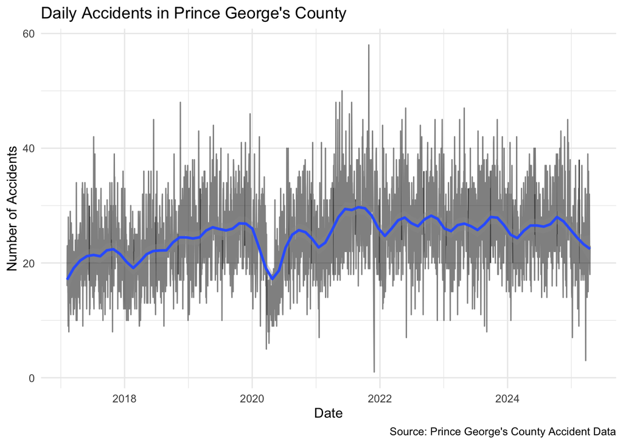

```r
# Plot time series
ggplot(accidents, aes(x = date, y = total)) +
  geom_line(alpha = 0.5) +
  geom_smooth(method = "loess", span = 0.1) +
  theme_minimal() +
  labs(title = "Daily Accidents in Prince George's County",
       x = "Date",
       y = "Number of Accidents",
       caption = "Source: Prince George's County Accident Data")
```

### Task 1 (3 points)

Looking at the time series visualization above, identify at least two noticeable patterns or anomalies. What questions would you want to investigate further based on this initial view of the data? How might these visual patterns translate into potential story angles?

The data shows fluctuations, suggesting there may be weekly or seasonal patterns in accidents, with some days spiking sharply above the norm. These coudl correspond to extreme weather or local events. Therefore it would be beneficial to explore which dates are most dangerous and see whether they coincide with any events in particular; this would provide potential story angles. The daily data is quite noisy, so let’s also look at weekly patterns:

```r
# Add day of week
accidents <- accidents |>
  mutate(
    day_of_week = wday(date, label = TRUE),
    month = floor_date(date, "month"),
    year = year(date)
  )

# Check accident patterns by day of week
day_of_week_summary <- accidents |>
  group_by(day_of_week) |>
  summarize(
    avg_accidents = mean(total),
    median_accidents = median(total),
    max_accidents = max(total),
    min_accidents = min(total)
  )

# Display day of week summary
day_of_week_summary |> kable(digits = 2)
```

| day_of_week | avg_accidents | median_accidents | max_accidents | min_accidents |
| --- | --- | --- | --- | --- |
| Sun | 25.24 | 25 | 45 | 3 |
| Mon | 22.95 | 23 | 41 | 1 |
| Tue | 23.12 | 23 | 45 | 8 |
| Wed | 22.91 | 23 | 45 | 7 |
| Thu | 23.63 | 23 | 43 | 8 |
| Fri | 27.96 | 28 | 58 | 9 |
| Sat | 27.71 | 27 | 50 | 10 |

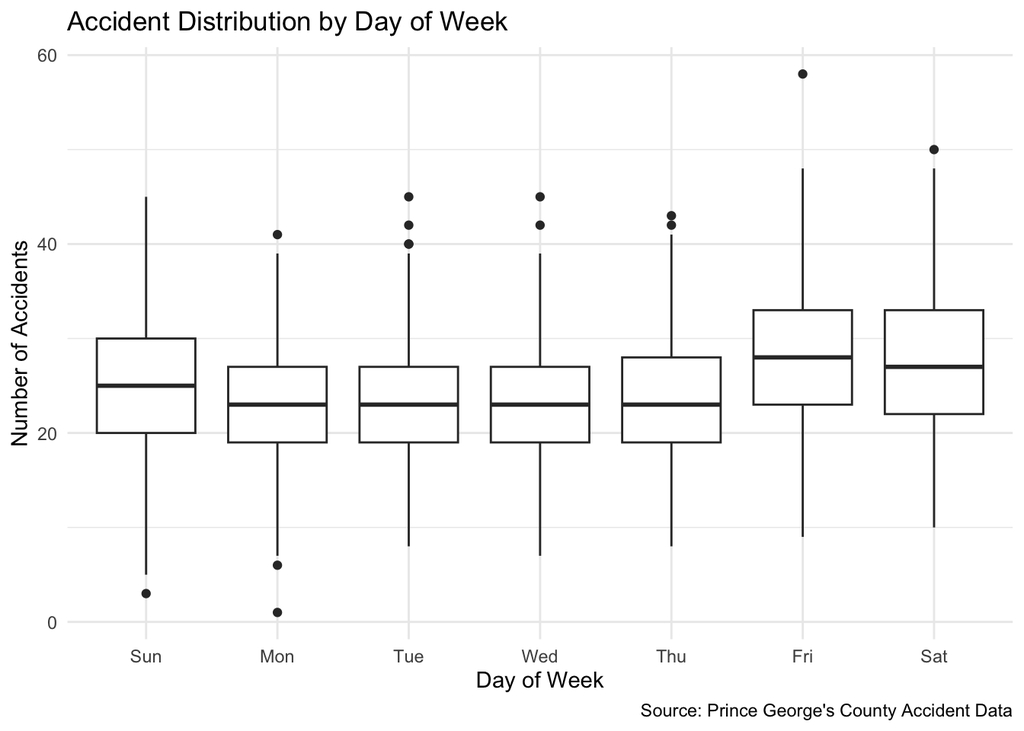

```r
# Visualize by day of week
ggplot(accidents, aes(x = day_of_week, y = total)) +
  geom_boxplot() +
  theme_minimal() +
  labs(title = "Accident Distribution by Day of Week",
       x = "Day of Week",
       y = "Number of Accidents",
       caption = "Source: Prince George's County Accident Data")
```

### Task 2 (2 points)

Based on the day-of-week analysis, which day(s) have the highest and lowest average accidents? Why might these patterns exist?

Based on the data, Friday has the highest avg number of accidents (27.96), with Saturday in second place (27.71), while Wednesday has the lowest average (22.91). Higher accidents on Fridays and Saturdays may be because of increased traffic from people running errands, or going out for social activities, while midweek days like Wednesday normally have lighter traffic trends.

## Calculating Z-Scores

Now, let’s calculate z-scores for our accident totals:

```r
# Calculate z-scores for total accidents
accidents <- accidents |>
  mutate(
    mean_accidents = mean(total),
    sd_accidents = sd(total),
    z_score = (total - mean_accidents) / sd_accidents
  )

# Display the data with z-scores
accidents |>
  select(date, day_of_week, total, z_score) |>
  head(10) |>
  kable(digits = 2)
```

| date | day_of_week | total | z_score |
| --- | --- | --- | --- |
| 2017-02-06 | Mon | 16 | -1.26 |
| 2017-02-07 | Tue | 23 | -0.26 |
| 2017-02-08 | Wed | 20 | -0.69 |
| 2017-02-09 | Thu | 16 | -1.26 |
| 2017-02-10 | Fri | 17 | -1.12 |
| 2017-02-11 | Sat | 16 | -1.26 |
| 2017-02-12 | Sun | 9 | -2.27 |
| 2017-02-13 | Mon | 28 | 0.46 |
| 2017-02-14 | Tue | 18 | -0.97 |
| 2017-02-15 | Wed | 14 | -1.55 |

## Identifying Unusual Days

Let’s identify days with unusually high or low accident numbers (|z-score| > 2):

```r
# Find days with unusual accident numbers
unusual_days <- accidents |>
  filter(abs(z_score) > 2) |>
  arrange(desc(abs(z_score)))

# Display number of unusual days
cat("Number of days with unusual accident counts:", nrow(unusual_days),
    "out of", nrow(accidents), "total days (",
    round(nrow(unusual_days)/nrow(accidents)*100, 2), "%)")
```

```
## Number of days with unusual accident counts: 132 out of 2983 total days ( 4.43 %)
```

```r
# Display the top 10 most unusual days
unusual_days |>
  head(10) |>
  select(date, day_of_week, total, z_score) |>
  kable(digits = 2)
```

| date | day_of_week | total | z_score |
| --- | --- | --- | --- |
| 2021-10-29 | Fri | 58 | 4.77 |
| 2021-05-29 | Sat | 50 | 3.62 |
| 2021-11-29 | Mon | 1 | -3.42 |
| 2018-11-16 | Fri | 48 | 3.33 |
| 2021-04-24 | Sat | 48 | 3.33 |
| 2021-05-15 | Sat | 48 | 3.33 |
| 2021-07-23 | Fri | 48 | 3.33 |
| 2022-05-28 | Sat | 47 | 3.19 |
| 2023-04-28 | Fri | 47 | 3.19 |
| 2025-03-23 | Sun | 3 | -3.13 |

### Task 3 (3 points)

Choose one of the top 10 unusual days and research what might have happened on that date. Look for weather events, holidays, major incidents, or other factors that could explain the unusual number of accidents. Briefly describe your findings and how you would incorporate this context into a story.

https://www.washingtonpost.com/dc-md-va/2021/10/29/flooding-roads-closed/ On October 29, 2021, PG County saw 58 accidents (z‑score 4.77), likely due to heavy rain and local flooding in the area. The weather made roads dangerous, driving the spike in accidents. A story could highlight how sudden storms and flooding increase traffic risks and accidents

Let’s visualize these unusual days:

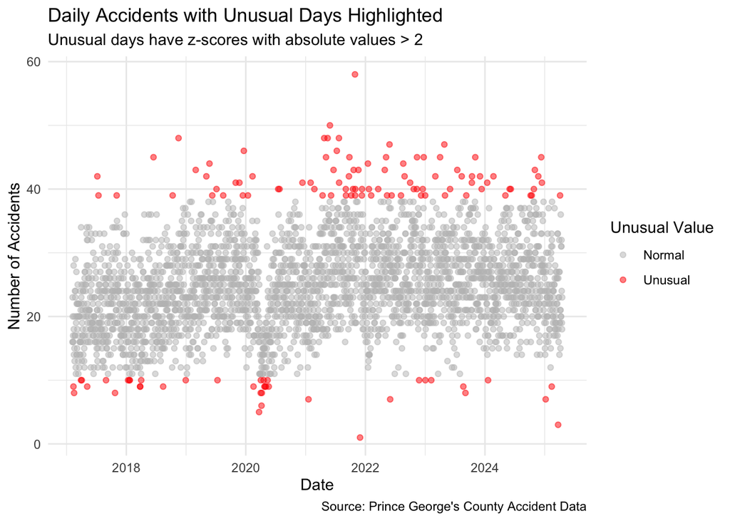

```r
# Highlight unusual days in the time series
ggplot(accidents, aes(x = date, y = total, color = abs(z_score) > 2)) +
  geom_point(alpha = 0.5) +
  scale_color_manual(values = c("gray", "red"),
                     name = "Unusual Value",
                     labels = c("Normal", "Unusual")) +
  theme_minimal() +
  labs(title = "Daily Accidents with Unusual Days Highlighted",
       subtitle = "Unusual days have z-scores with absolute values > 2",
       x = "Date",
       y = "Number of Accidents",
       caption = "Source: Prince George's County Accident Data")
```

## Day of Week Patterns

Let’s calculate z-scores that account for day of week patterns:

```r
# Calculate day-of-week adjusted z-scores
accidents <- accidents |>
  group_by(day_of_week) |>
  mutate(
    dow_mean = mean(total),
    dow_sd = sd(total),
    dow_z_score = (total - dow_mean) / dow_sd
  ) |>
  ungroup()

# Find days with unusual day-of-week z-scores
unusual_dow <- accidents |>
  filter(abs(dow_z_score) > 2) |>
  arrange(desc(abs(dow_z_score)))

# Display the top unusual days adjusted for day of week
unusual_dow |>
  head(10) |>
  select(date, day_of_week, total, dow_mean, dow_z_score) |>
  kable(digits = 2)
```

| date | day_of_week | total | dow_mean | dow_z_score |
| --- | --- | --- | --- | --- |
| 2021-10-29 | Fri | 58 | 27.96 | 4.17 |
| 2021-05-05 | Wed | 45 | 22.91 | 3.65 |
| 2021-11-29 | Mon | 1 | 22.95 | -3.45 |
| 2024-12-10 | Tue | 45 | 23.12 | 3.42 |
| 2021-10-21 | Thu | 43 | 23.63 | 3.18 |
| 2025-03-23 | Sun | 3 | 25.24 | -3.16 |
| 2021-09-22 | Wed | 42 | 22.91 | 3.15 |
| 2021-05-29 | Sat | 50 | 27.71 | 3.04 |
| 2024-02-22 | Thu | 42 | 23.63 | 3.01 |
| 2020-02-11 | Tue | 42 | 23.12 | 2.95 |

### Task 4 (3 points)

Compare the days that have extreme z-scores overall versus those with extreme day-of-week z-scores. How do these lists differ? What journalistic insights can you draw from comparing these two different approaches to measuring “unusual” days?

Comparing the two, overall z-scores flag the days with unusually high or low accident comparing all days, while DOW z-scores identify days that are extreme compared to the avg accident count for that specific weekday. To prove this, a Saturday with 50 accidents might be unusual overall, but less extreme compared to other Saturdays. Looking at this from a journalism standpoint, overall z-scores pinpoint the most shocking spikes/drops, while DOW z-scores show unexpected numbers within normal weekly patterns. This helps reporters figure out whether a day’s accidents were surprising for that weekday or just part of a bigger trend.

Let’s see how many unusual days we have for each day of the week:

```r
# Count unusual days by day of week
unusual_count_by_dow <- accidents |>
  filter(abs(dow_z_score) > 2) |>
  count(day_of_week) |>
  arrange(desc(n))

# Get total count by day of week for comparison
total_by_dow <- accidents |>
  count(day_of_week)

# Join to calculate percentages
unusual_rates <- unusual_count_by_dow |>
  left_join(total_by_dow, by = "day_of_week") |>
  rename(unusual_days = n.x, total_days = n.y) |>
  mutate(
    pct_unusual = (unusual_days / total_days) * 100
  )

# Display results
unusual_rates |> kable(digits = 2)
```

| day_of_week | unusual_days | total_days | pct_unusual |
| --- | --- | --- | --- |
| Sun | 22 | 425 | 5.18 |
| Mon | 22 | 427 | 5.15 |
| Tue | 22 | 427 | 5.15 |
| Thu | 20 | 427 | 4.68 |
| Fri | 18 | 426 | 4.23 |
| Wed | 17 | 427 | 3.98 |
| Sat | 16 | 424 | 3.77 |

## Monthly Patterns

Let’s examine if certain months have more unusual days:

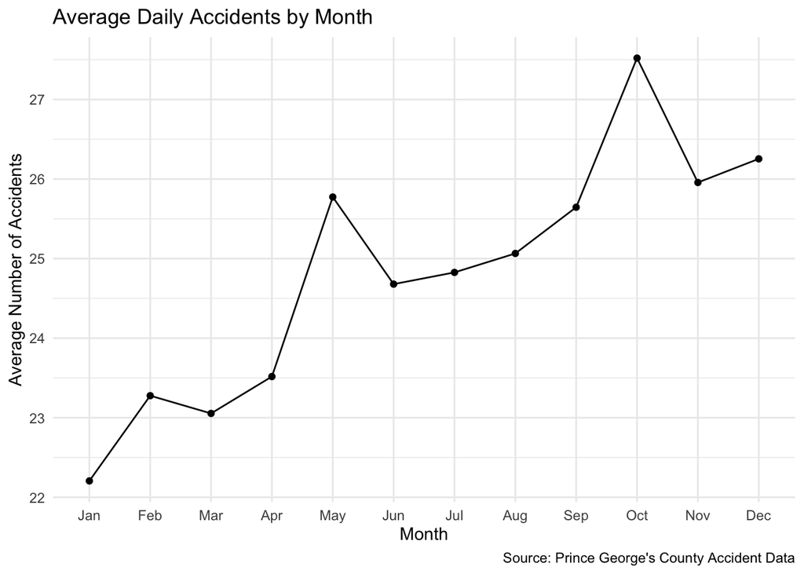

```r
# Extract month from date for seasonal analysis
accidents <- accidents |>
  mutate(month_of_year = month(date, label = TRUE))

# Calculate average accidents by month
monthly_pattern <- accidents |>
  group_by(month_of_year) |>
  summarize(
    avg_accidents = mean(total),
    median_accidents = median(total)
  )

# Plot monthly pattern
ggplot(monthly_pattern, aes(x = month_of_year, y = avg_accidents, group = 1)) +
  geom_line() +
  geom_point() +
  theme_minimal() +
  labs(title = "Average Daily Accidents by Month",
       x = "Month",
       y = "Average Number of Accidents",
       caption = "Source: Prince George's County Accident Data")
```

```r
# Calculate month-adjusted z-scores
accidents <- accidents |>
  group_by(month_of_year) |>
  mutate(
    monthly_mean = mean(total),
    monthly_sd = sd(total),
    monthly_z_score = (total - monthly_mean) / monthly_sd
  ) |>
  ungroup()

# Find days with unusual monthly z-scores
unusual_monthly <- accidents |>
  filter(abs(monthly_z_score) > 2) |>
  arrange(desc(abs(monthly_z_score)))

# Display top days that are unusual for their month
unusual_monthly |>
  head(10) |>
  select(date, month_of_year, day_of_week, total, monthly_mean, monthly_z_score) |>
  kable(digits = 2)
```

| date | month_of_year | day_of_week | total | monthly_mean | monthly_z_score |
| --- | --- | --- | --- | --- | --- |
| 2021-10-29 | Oct | Fri | 58 | 27.52 | 4.41 |
| 2021-11-29 | Nov | Mon | 1 | 25.96 | -3.54 |
| 2021-07-23 | Jul | Fri | 48 | 24.83 | 3.53 |
| 2022-01-16 | Jan | Sun | 44 | 22.21 | 3.35 |
| 2021-07-10 | Jul | Sat | 46 | 24.83 | 3.23 |
| 2021-04-24 | Apr | Sat | 48 | 23.52 | 3.21 |
| 2021-05-29 | May | Sat | 50 | 25.77 | 3.20 |
| 2018-11-16 | Nov | Fri | 48 | 25.96 | 3.13 |
| 2023-04-28 | Apr | Fri | 47 | 23.52 | 3.08 |
| 2025-03-23 | Mar | Sun | 3 | 23.05 | -3.05 |

### Task 5 (2 points)

Based on the monthly pattern analysis, which months have the highest and lowest average accidents? Develop a hypothesis about why these seasonal patterns exist.

The month with the highest avg is October (27.52), while the lowest is January (22.21). This pattern appears to be seasonal and could be because of increased travel and the worsening weather in the fall(e.g.heavier rain). and it getting dark out earlier. Whereas January normally has less trips and weather is either very snowy or just cold with less of a chance of rain. When it snows the average person chooses not to drive and uses public transport, reducing traffic on the road and therefore accidents.

## Identifying Extreme Outliers

Let’s look specifically at days with extremely unusual accident counts (z-scores beyond ±3):

```r
# Find extreme outliers
extreme_outliers <- accidents |>
  filter(abs(z_score) > 3) |>
  arrange(desc(abs(z_score)))

# Display extreme outliers
if(nrow(extreme_outliers) > 0) {
  extreme_outliers |>
    select(date, day_of_week, total, z_score) |>
    kable(digits = 2)
} else {
  cat("No days with z-scores beyond ±3 were found in the dataset.")
}
```

| date | day_of_week | total | z_score |
| --- | --- | --- | --- |
| 2021-10-29 | Fri | 58 | 4.77 |
| 2021-05-29 | Sat | 50 | 3.62 |
| 2021-11-29 | Mon | 1 | -3.42 |
| 2018-11-16 | Fri | 48 | 3.33 |
| 2021-04-24 | Sat | 48 | 3.33 |
| 2021-05-15 | Sat | 48 | 3.33 |
| 2021-07-23 | Fri | 48 | 3.33 |
| 2022-05-28 | Sat | 47 | 3.19 |
| 2023-04-28 | Fri | 47 | 3.19 |
| 2025-03-23 | Sun | 3 | -3.13 |
| 2019-12-20 | Fri | 46 | 3.05 |
| 2021-07-10 | Sat | 46 | 3.05 |

### Task 6 (2 points)

For the extreme outliers identified (z-scores beyond ±3), what do they have in common?

## Your Best Story Pitch

### Task 7 (5 points)

Based on all the analyses performed, craft your best story pitch, including a headline and lede. Be sure to include what kinds of sources/people you’d talk to for the story.

When Does Driving Get the Most Dangerous? How the Data Reflects Weekends and Weather as the Deciding Factors

From sudden storms to busy weekends, Prince George’s County experiences spikes in car accidents, with some days seeing more than double the usual crashes. Analysis of accident data reveals Fridays and Saturdays consistently produce the highest accident counts, while unusual events like severe weather can create record-breaking spikes.

Sources: Sources I could interview include local traffic authorities or police who deal with the accidents and what trends they personally identify. Residents or drivers for the human perspective for when they avoid travelling.